# Logboek_Yamila_Medulloblastoma

2024-09-22

# Week 1

## Het doel/opzet van de cursus

Voor week 1 vind ik het belangrijk om duidelijk te krijgen wat het doel is van deze cursus, aan de hand van de informatie op Blackboard ben ik tot de volgende conclusie gekomen: het doel van deze course is om te leren een pipeline te ontwikkelen, met behulp van Galaxy, die voor een ziekte kan voorspellen of een patiënt mogelijk variaties heeft in zijn genoom die aan de ziekte kunnen worden gelinkt. Ik heb samen met mijn groepsgenoot gekozen voor ‘*medulloblastoma*’ als aandoening. De reden dat wij hiervoor hebben gekozen is omdat dit een van de meest voorkomende vormen van kanker is bij jonge kinderen, maar er toch nog maar weinig bekend is over de exacte oorzaak.

Vragen die wij willen onderzoeken zijn o.a.;

- Welke SNP’s er voorkomen bij medulloblastomen,
- Welke tools wij het beste kunnen gebruiken in Galaxy.

- ```
    Er zijn namelijk allerlei tools beschikbaar, maar niet alle tools passen goed bij dit onderzoek.
  ```

Voor deze analyse zullen wij de medulloblastoom DNA-seq data (MB-DNASeq) gebruiken. Deze is terug te vinden op het BIN-netwerk in de volgende locatie: /commons/Themas/Thema05/2024/. Deze data bevat 5 verschillende samples, waarvan wij de sample van patiënt 5 zullen gebruiken (SRR26913194). De data voor deze sample bestaat uit 2 FASTQ-bestanden, met de forward (_1)- en reverse (_2) read, de data bestaat uit next-generation Illumina NextSeq 500 reads (paired-end) en bestaat uit de exomen van bepaalde genen in een vooraf opgesteld genpanel. Dit genpanel bevat 130 genen die met het ontstaan van kanker in verband worden gebracht. Door een ‘klein’ genpanel op te stellen van 130 genen, in plaats van alle 26.564 menselijke genen te sequencen, kunnen er meer reads worden verkregen van de genen die daadwerkelijk interessant zijn bij het ontstaan van deze aandoening.

De applicaties die wij voor dit project zullen gebruiken zijn:

- De wetenschappelijke workflow manager Galaxy, voor de analyse,
- R voor het bijhouden van de bevindingen en de manier waarop de analyse is uitgevoerd, dit vind plaats in de vorm van een logboek,
- Github voor het delen van bestanden.

De tools die wij op Galaxy zullen gebruiken om de analyse uit te voeren zijn: - Quality Control: - FASTQC - Trimmomatic - Mapping: - BWA - Variant detection: - LoFreq

## Achtergrondinformatie medulloblastoma

Voordat ik ben begonnen met het gebruik van Galaxy, heb ik informatie opgezocht over medulloblastomen, om te achterhalen wat deze aandoening inhoudt, op wie het vooral effect heeft en waarom het belangrijk is om hier onderzoek naar te doen.

Medulloblastomen vormen de meestvoorkomende maligne hersentumor in kinderen, namelijk bijna 20%. Medullablastomen zijn een embryonale neuroepitheliale tumor in het cerebellum [afbeelding 1], dit houdt in dat de tumor ontstaat vanuit bepaalde embryonale stamcellen. Behandeling bestaat uit een combinatie van het chirurgisch verwijderen van de tumor, met daarop volgend radio-en chemotherapie. De 5-jaar overlevingskans lijkt nog niet heel duidelijk onderzocht en is volgens de literatuur tussen de 20 en 90 procent. Deze grote range is te danken aan het feit dat veel verschillende factoren een rol spelen bij de overlevingskans, bijvoorbeeld de leeftijd wanneer de aandoening wordt vastgesteld, de aanwezigheid van metastasen (uitzaaiingen) en afwijkingen in het genoom, denk hierbij aan copy-number variations. Hierbij kan het zijn dat er van bepaalde genen meer of minder kopieeen voorkomen, in het geval dat het een gen is dat te maken heeft met bijvoorbeeld de celdeling, kan dit de kans op kanker sterk verhogen. Medulloblastoom is een ‘high-grade’ tumor (snel delend) en heeft een grote kans om uit te zaaien in het hersenvocht (Mahapatra S 2023).

Het is onbekend wat de oorzaak is van medulloblastomen, uit meerdere onderzoeken blijkt dat er een mogelijke link is tussen het dieet van de moeder tijdens de zwangerschap of de aanwezigheid van auto-immuun/bloedziekten. Ook zijn bepaalde virale infecties mogelijk een oorzaak, zoals virale John Cunningham infecties of human cytomegalovirus infections tijdens kindertijd. Ook wordt er gedacht dat erfelijkheid een rol speelt en dat bepaalde aandoeningen de kans verhogen op het ontstaan van medullablastomen, dit zijn: Gorlinsyndroom, Fanconi anemie, Turcotsyndroom, Li-Fraumeni syndroom (Mahapatra S 2023).

Het is duidelijk dat er nog veel onbekend is over de exacte etiologie van deze aandoening en juist omdat deze aandoening een van de meest voorkomende vormen van kanker is bij (jonge) kinderen, denk ik dat het maatschappelijk erg belangrijk is om hier verder onderzoek naar te doen. In de literatuur wordt onder andere copy-number variation en erfelijkheid vermeld, dit zijn beide onderdelen die kunnen worden onderzocht door mapping aan de hand van een referentiegenoom.

[figure not shown]

Weergave van locatie van medulloblastoom, in het cerebellum (Staff 2023)

## Galaxy tutorial

Nu ik een beter beeld heb gekregen van de aandoening heb ik besloten om te beginnen met Galaxy, voordat ik aan de daadwerkelijke opdracht ben begonnen heb ik een Galaxy tutorial gevolgd, om bekend te raken met de workflow manager. De tutorial die ik hiervoor heb gebruikt is ‘*Galaxy Basics for genomics*’, afkomstig van de volgende website: https://galaxyproject.github.io/training-material/topics/introduction/tutorials/galaxy-intro-101/tutorial.html

In deze tutorial heb ik geleerd om: - Een history aan te maken - Bestanden in te laden - Tools te gebruiken (datamash, intersect intervals, sort, select first, compare two datasets) - Een history om te zetten naar een workflow

## Quality Control met Galaxy

### Input

Forward en reverse read van sample 5:

- SRR26913194_1.fastq
- SRR26913194_2.fastq

| Input Parameter | Value |
| --- | --- |
| Raw read data from your current history | 1: SRR26913194_1.fastq.gz |
| Contaminant list |  |
| Adapter list |  |
| Submodule and Limit specifing file |  |
| Disable grouping of bases for reads >50bp | 0 |
| Lower limit on the length of the sequence to be shown in the report | Not available. |
| Length of Kmer to look for | 7 |

| Input Parameter | Value |
| --- | --- |
| Raw read data from your current history | 1: SRR26913194_2.fastq.gz |
| Contaminant list |  |
| Adapter list |  |
| Submodule and Limit specifing file |  |
| Disable grouping of bases for reads >50bp | 0 |
| Lower limit on the length of the sequence to be shown in the report | Not available. |
| Length of Kmer to look for | 7 |

### Output:

- Webpage
- Raw data

### Resultaten

#### Basic statistics

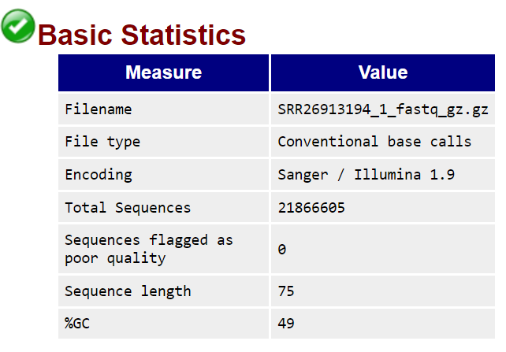

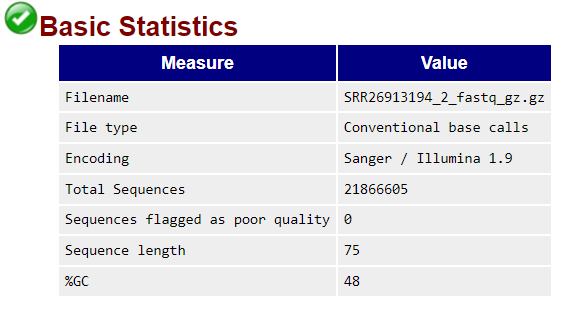

De basic statistics tussen de forward en reverse read lijken sterk met elkaar overeen te komen, op 1 onderdeel na, zo is het GC-gehalte bij de reverse read 1% lager en verwacht ik dat de GC-gehalte normaalverdeling bij de reverse read meer zal afwijken dan de forward read.

#### Summary

Wat opvalt in de summary van het FASTQC rapport voor zowel SRR26913194_1 als SRR26913194_2, is dat er een failure wordt gegeven bij ‘*per sequence GC content*’ en een warning bij ‘*sequence duplication levels*’. Om te kijken wat dit betekent, ga ik kijken naar de documentatie van FASTQC.

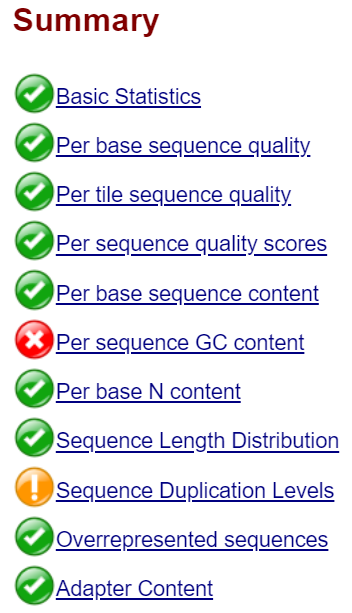

Summary uit FastQC Report, forward read

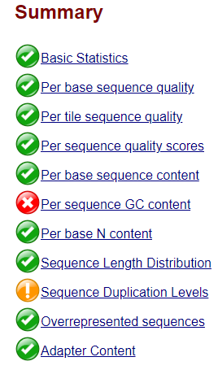

Summary uit FastQC Report, reverse read

#### Per sequence GC content

FASTQC meet het GC-gehalte van de gehele sequentie in een bestand en vergelijkt dit met een gemodelleerde normaalverdeling van het GC-gehalte. In een willekeurige library wordt er verwacht dat er ongeveer een normaalverdeling is van het GC-gehalte. Wanneer dit niet het geval is, en er een afwijkende vorm te zien is, kan dit wijzen op een probleem met de library. Een scherpe piek op de verdeling kan een gevolg zijn van een specifieke contaminant (bijv. van adapters), een bredere piek kan duiden op contaminatie met een andere soort. Een failure bij dit onderdeel houdt in dat de totale deviatie van de normaalverdeling gelijk is aan meer dan 30% van de reads (Bioinformatics, n.d.).

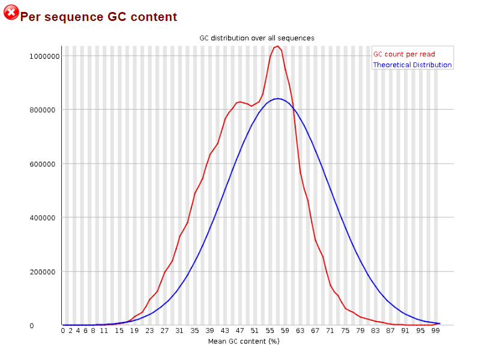

GC-gehalte uit FastQC Report, forward read

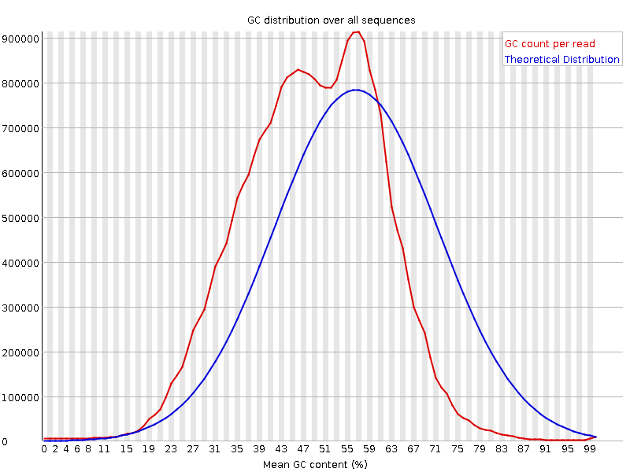

GC-gehalte uit FastQC Report, reverse read

#### Sequence duplication levels

Normaal horen sequenties maar één keer voor te komen in de uiteindelijke dataset, een lage hoeveelheid aan duplicaties van sequenties duidt op een hoge coverage van de target sequentie, maar een hoge hoeveelheid aan duplicaties kan het gevolg zijn van een bias. Deze module telt het aantal duplicaten voor elke sequentie in een library en maakt hiervan een plot, met het percentage van de sequentie en de bijbehorende hoeveelheid duplicaten. Hierbij Kijkt het alleen naar de eerste 100.000 sequenties van de data om geheugen te besparen, omdat dit genoeg is om een goed beeld te vormen. Dit onderdeel laat een warning zien als meer dan 20% van de data bestaat uit niet-unieke sequenties(Bioinformatics, n.d.).

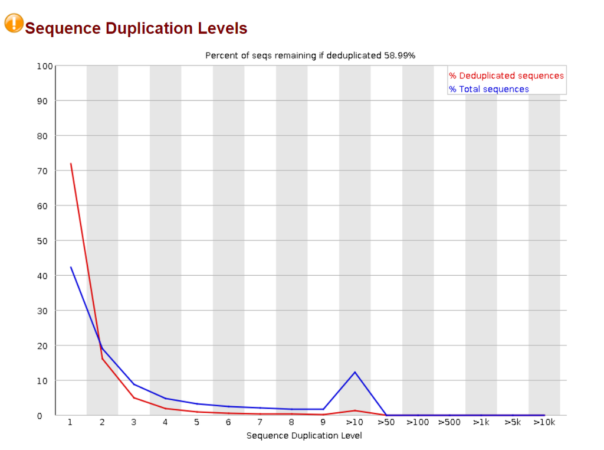

Sequence Duplication Levels uit FastQC Report, forward read

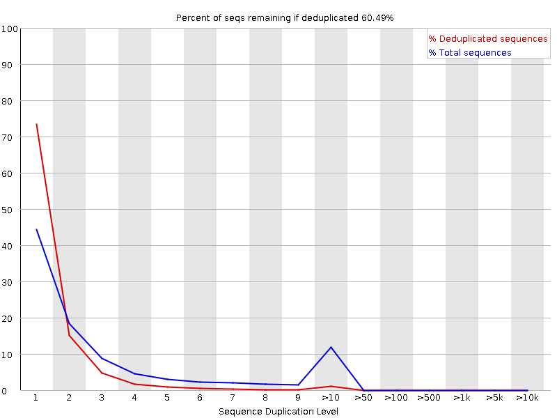

Sequence Duplication Levels uit FastQC Report, reverse read

## **Tool Parameters**

[output not shown]

Bioinformatics, Babraham. n.d. “FastQC a Quality Control Tool for High Throughput Sequence Data.” https://www.bioinformatics.babraham.ac.uk/projects/fastqc/.

Mahapatra S, Amsbaugh MJ. 2023. “Medulloblastoma.” *StatPearls [Internet]. Treasure Island (FL)*. StatPearls Publishing. https://www.ncbi.nlm.nih.gov/books/NBK431069/.

Staff, Mayo Clinic. 2023. “Medulloblastoma.” https://www.mayoclinic.org/diseases-conditions/medulloblastoma/cdc-20363524.